# Assignment 3-Task 3: Santa Barbara Urchins

Kerry Nixon

11/2/2020

**Data Source:** Reed, D. 2020. SBC LTER: Reef: Long-term experiment: Kelp removal: Urchin size frequency distribution ver 20. Environmental Data Initiative. https://doi.org/10.6073/pasta/5a1e9ef03aa47bd2225c0bb98a02a63b.

```r
# Reading in the data & naming it as an object in R
urchins_data <- read.csv(here("data","urchins.csv")) %>%
  clean_names() # Changing column headers to lower case snake case
```

## Section 1: Comparing Size of Purple and Red Urchins

(include data from all sites, and for both treatments - i.e. ignore those variables in this exploration)

#### Exploratory data visualization:

I will now do some exploratory data visualization to compare the distribution of sizes between purple and red urchins using a faceted histogram plot and box plots.

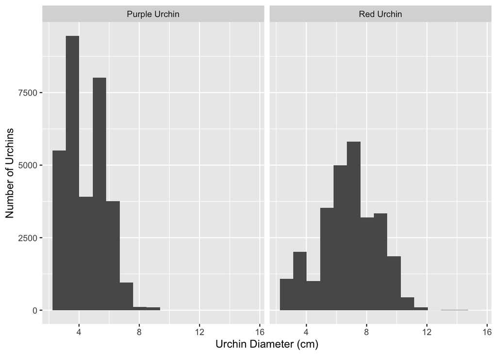

```r
# exploratory histograms showing size distribution by species
ggplot(data = urchins_data, aes(x = size)) +
  geom_histogram(bins = 15) +
  facet_wrap(~common_name) +
  labs(x = "Urchin Diameter (cm)",
       y = "Number of Urchins")
```

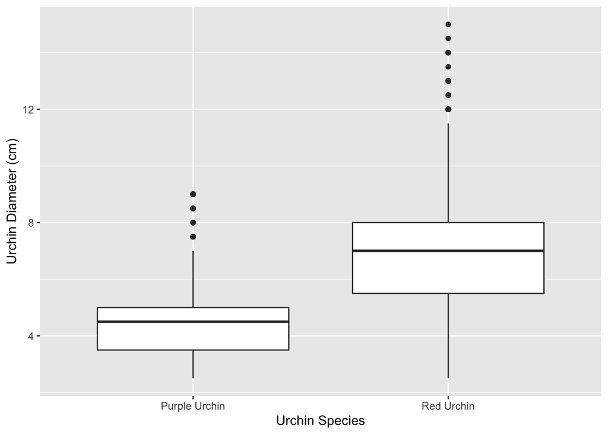

```r
# exploratory box plot showing size distribution, and relative summary stats by species
ggplot(data = urchins_data, aes(x = common_name, y = size)) +
  geom_boxplot() +
  labs(x = "Urchin Species",
       y = "Urchin Diameter (cm)")
```

#### Descriptive statistics:

To further interrogate the data, I will generate some basic summary statistics for each sample group to use for basic comparison.

```r
# Summary statistics table using group_by() %>% summarise()
urchins_summary <- urchins_data %>%
  group_by(common_name) %>%
  summarise(mean_diameter_cm = mean(size),
            median_diameter_cm = median(size),
            standard_deviation_cm = sd(size),
            sample_size = n())

# Returning the summary table, formatting it
kbl(urchins_summary) %>%
  kable_styling(full_width = FALSE, "hover")
```

| common_name | mean_diameter_cm | median_diameter_cm | standard_deviation_cm | sample_size |
| --- | --- | --- | --- | --- |
| Purple Urchin | 4.469797 | 4.5 | 1.175264 | 31805 |
| Red Urchin | 6.776489 | 7.0 | 1.891343 | 27408 |

**Observations and Analysis:** When reviewing the exploratory histograms, it appears that the distribution of the sample for purple urchins is slightly positively skewed, while the sample distribution for red urchins looks to be more normally distributed. When viewing the sample distribution box plots there appears to be a fair amount of variance between the samples, the sample means and interquartile ranges do not overlap. The red urchin sample has more dispersion within the sample than the purple urchin sample. The difference in median diameter is 2.5 cm, which represents a sizable 43.47% difference (|x<sub>1</sub>-x<sub>2</sub>|/(x<sub>1</sub>+x<sub>2</sub>/2)*100) in median diameter between the two samples. Likewise, the sample means are approximately 2.31 cm apart, representing a 41.07% difference in mean urchin diameter. This would indicate that it is more ikely that the samples are from the populations with different means, rather than one population with the same mean. The large sample sizes used to analyze both species reduces the level of uncertainty in this regard.

## Section 2. Exploring purple urchin counts by site and year

```r
# Creating a stored subset of purple urchin data
purple_urchins <- urchins_data %>%
  filter(common_name == "Purple Urchin") %>%
  mutate(date = mdy(date)) %>%
  mutate(year = year(date)) %>%
  mutate(site_full = case_when(
    site == "NAPL" ~ "Naples Reef",
    site == "AQUE" ~ "Arroyo Quemado Reef",
    site == "CARP" ~ "Carpinteria Reef",
    site == "MOHK" ~ "Mohawk Reef",
    site == "IVEE" ~ "Isla Vista Reef"))

# Generating a summary table containing total counts of purple urchins observed by site and year
purple_urchin_summary <- purple_urchins %>%
  group_by(site_full, year) %>%
  count()

# Returning the summary table
purple_urchin_summary
```

```
## # A tibble: 61 x 3
## # Groups:   site_full, year [61]
##    site_full            year     n
##    <chr>               <dbl> <int>
##  1 Arroyo Quemado Reef  2008    67
##  2 Arroyo Quemado Reef  2009   926
##  3 Arroyo Quemado Reef  2010   921
##  4 Arroyo Quemado Reef  2011   887
##  5 Arroyo Quemado Reef  2012   764
##  6 Arroyo Quemado Reef  2013   434
##  7 Arroyo Quemado Reef  2014   410
##  8 Arroyo Quemado Reef  2015   400
##  9 Arroyo Quemado Reef  2016   342
## 10 Arroyo Quemado Reef  2017   406
## # … with 51 more rows
```

#### Exploratory Graphs of Annual Purple Urchin Counts by Site

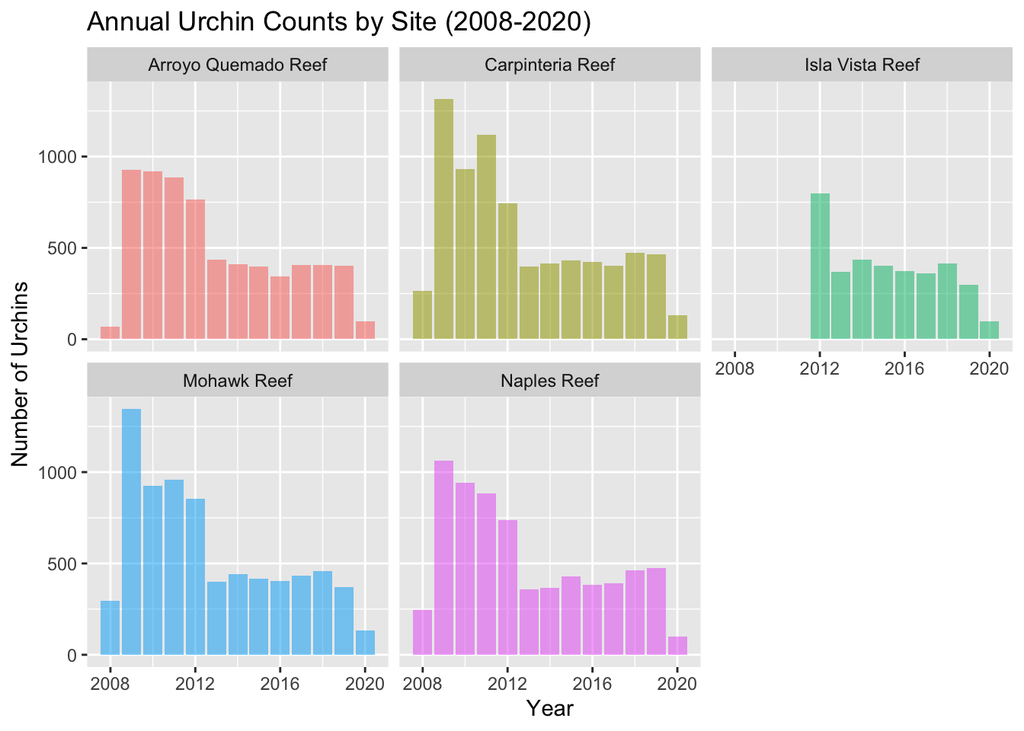

```r
#Exploratory graph of annual urchin counts by site
purple_urchin_summary %>%
ggplot(aes(x = year, y = n)) +
  geom_bar(stat = "identity",
           show.legend = FALSE,
           aes(fill = site_full,
               alpha = 0.9)) +
  facet_wrap(~ site_full) +
  labs(x = "Year",
       y = "Number of Urchins",
       title = "Annual Urchin Counts by Site (2008-2020)") +
  theme_gray()
```

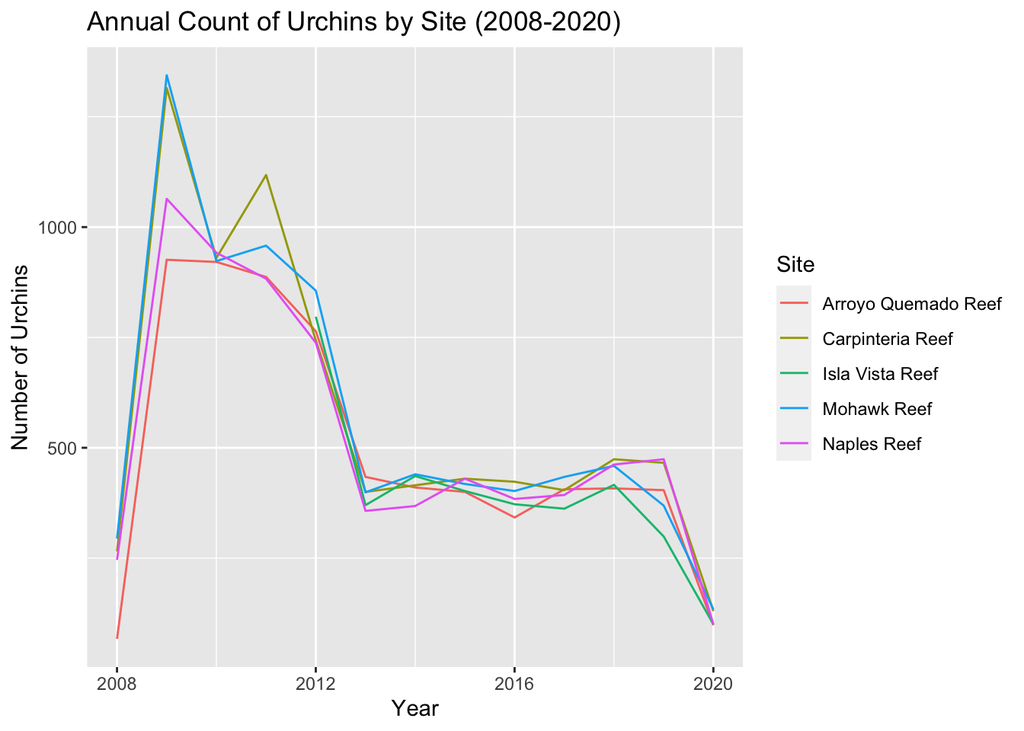

```r
ggplot(purple_urchin_summary,
       aes(x = year, y = n)) +
  geom_line(aes(color = site_full)) +
  scale_x_continuous(breaks = c(2008, 2012,2016, 2020)) +
  labs(x = "Year",
       y = "Number of Urchins",
       title = "Annual Count of Urchins by Site (2008-2020)",
       color = "Site")
```